# GlobalBodySize: Science Summary

# 4. Cross-Provider Mass Comparison

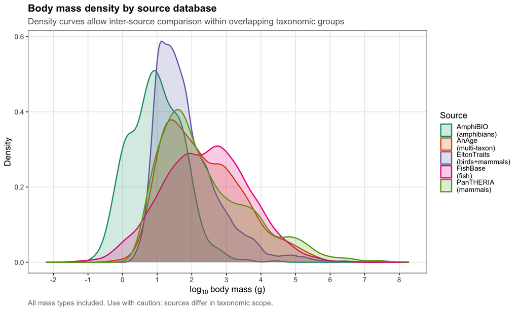

Fig. 3. Body mass distribution per provider source. Useful for detecting systematic offsets between databases. Overlapping distributions indicate reasonable inter-source agreement; divergence warrants investigation.

```r
provider_plot_dat <- dat |>
  dplyr::filter(!is.na(log10_mass), is.finite(log10_mass)) |>
  dplyr::mutate(
    ## Shorten source labels for plot
    source_short = dplyr::case_when(
      grepl("PanTHERIA",   source_display_name) ~ "PanTHERIA\n(mammals)",
      grepl("EltonTraits", source_display_name) ~ "EltonTraits\n(birds+mammals)",
      grepl("AnAge",       source_display_name) ~ "AnAge\n(multi-taxon)",
      grepl("AmphiBIO",    source_display_name) ~ "AmphiBIO\n(amphibians)",
      grepl("FishBase",    source_display_name) ~ "FishBase\n(fish)",
      grepl("AVONET",      source_display_name) ~ "AVONET\n(birds)",
      TRUE                                       ~ source_display_name
    )
  )

ggplot(provider_plot_dat,
       aes(x = log10_mass, colour = source_short, fill = source_short)) +
  geom_density(alpha = 0.2, linewidth = 0.8) +
  scale_x_continuous(
    name   = expression(log[10]~"body mass (g)"),
    breaks = -2:8
  ) +
  scale_y_continuous(name = "Density") +
  scale_colour_brewer(palette = "Dark2", name = "Source") +
  scale_fill_brewer(palette = "Dark2", name = "Source") +
  labs(
    title    = "Body mass density by source database",
    subtitle = "Density curves allow inter-source comparison within overlapping taxonomic groups",
    caption  = "All mass types included. Use with caution: sources differ in taxonomic scope."
  ) +
  theme(legend.position = "right")
```

# 5. Mass Type and Data Quality Composition

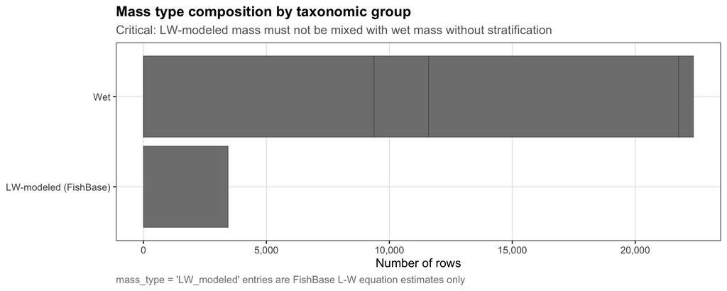

Fig. 4. Composition of mass_type field. LW-modeled entries are FishBase only. All other sources contribute directly measured or literature-mean values. Analyses mixing mass types require explicit sensitivity testing.

```r
mt_summary <- dat |>
  dplyr::filter(!is.na(mass_g), mass_g > 0) |>
  dplyr::count(mass_type_display, group_display) |>
  dplyr::arrange(dplyr::desc(n))

ggplot(mt_summary, aes(x = reorder(mass_type_display, n), y = n, fill = group_display)) +
  geom_col(colour = "grey30", linewidth = 0.2) +
  scale_fill_manual(values = GROUP_COLOURS, name = "Group") +
  scale_y_continuous(labels = scales::comma, name = "Number of rows") +
  coord_flip() +
  labs(
    title    = "Mass type composition by taxonomic group",
    subtitle = "Critical: LW-modeled mass must not be mixed with wet mass without stratification",
    caption  = "mass_type = 'LW_modeled' entries are FishBase L-W equation estimates only",
    x        = NULL
  )
```

```r
## Confidence breakdown
conf_tbl <- dat |>
  dplyr::filter(!is.na(mass_g), mass_g > 0) |>
  dplyr::count(mass_confidence, source_display_name) |>
  tidyr::pivot_wider(names_from = mass_confidence, values_from = n, values_fill = 0)

conf_tbl |>
  knitr::kable(
    caption = "Table 2. Row counts by mass_confidence flag and source. 'high' = directly measured literature mean; 'medium' = LW-modeled or derived."
  )
```

Table 2. Row counts by mass_confidence flag and source. ‘high’ = directly measured literature mean; ‘medium’ = LW-modeled or derived.

| source_display_name | high | low | medium |
| --- | --- | --- | --- |
| AnAge Build 14 (de Magalhães & Costa 2009) | 39 | 90 | 498 |
| EltonTraits 1.0 — Birds (Wilman et al. 2014) | 9993 | 0 | 0 |
| PanTHERIA v1.0 (Jones et al. 2009) | 3542 | 0 | 0 |
| AmphiBIO (Oliveira et al. 2017) | 0 | 0 | 591 |
| EltonTraits 1.0 — Mammals (Wilman et al. 2014) | 0 | 0 | 5400 |
| FishBase via rfishbase | 0 | 0 | 5657 |

# 6. Taxonomic Reconciliation Summary

```r
if (using_reconciled && "match_type" %in% names(dat)) {
  ## Reconciliation match type breakdown
  match_summary <- dat |>
    dplyr::count(match_type, match_confidence) |>
    dplyr::arrange(dplyr::desc(n))

  match_summary |>
    knitr::kable(
      col.names = c("GBIF match type", "Match confidence", "Rows"),
      caption   = paste0(
        "Table 3. GBIF Backbone reconciliation results (version: ",
        if ("backbone_version" %in% names(dat)) dat$backbone_version[1] else "unknown",
        "). EXACT matches have high confidence that the verbatim name resolves unambiguously."
      )
    )
} else {
  cat("Reconciled data not available in this file. Run scripts/run_taxon_reconciliation.R.\n")
}
```

Table 3. GBIF Backbone reconciliation results (version: GBIF_Backbone_2023-08-28). EXACT matches have high confidence that the verbatim name resolves unambiguously.

| GBIF match type | Match confidence | Rows |
| --- | --- | --- |
| EXACT | high | 23242 |
| EXACT | medium | 1982 |
| HIGHERRANK | medium | 389 |
| VARIANT | low | 132 |
| VARIANT | medium | 40 |
| NONE | low | 25 |

```r
if (using_reconciled && "matched_status" %in% names(dat)) {
  syn_rate <- mean(grepl("SYNONYM", dat$matched_status, ignore.case = TRUE), na.rm = TRUE)
  n_syn    <- sum(grepl("SYNONYM", dat$matched_status, ignore.case = TRUE), na.rm = TRUE)
  n_none   <- sum(dat$matched_status %in% c("NONE", "error"), na.rm = TRUE)

  cat(sprintf(
    "Synonym rate: %.1f%% (%d of %d rows carry a name that is a GBIF synonym)\n",
    100 * syn_rate, n_syn, nrow(dat)
  ))
  cat(sprintf("Unresolved names: %d rows (%.2f%%) — require manual review\n",
              n_none, 100 * n_none / nrow(dat)))
  cat(sprintf("\nNote: Synonym resolution does not change the analysis data — verbatim\n"))
  cat(sprintf("source names are preserved. accepted_name column carries the GBIF-preferred name.\n"))
}
```

```
## Synonym rate: 7.9% (2033 of 25810 rows carry a name that is a GBIF synonym)
## Unresolved names: 0 rows (0.00%) — require manual review
##
## Note: Synonym resolution does not change the analysis data — verbatim
## source names are preserved. accepted_name column carries the GBIF-preferred name.
```

```r
if (using_reconciled && "class" %in% names(dat)) {
  class_summary <- dat |>
    dplyr::filter(!is.na(class), nzchar(class), !is.na(mass_g), mass_g > 0) |>
    dplyr::count(class) |>
    dplyr::arrange(dplyr::desc(n))

  class_summary |>
    knitr::kable(
      col.names = c("GBIF-matched class", "Rows"),
      caption   = "Table 4. Row counts by GBIF-reconciled class. Reveals the actual taxonomic breadth of the dataset beyond the coarse input_taxonomic_group labels."
    )
}
```

Table 4. Row counts by GBIF-reconciled class. Reveals the actual taxonomic breadth of the dataset beyond the coarse input_taxonomic_group labels.

| GBIF-matched class | Rows |
| --- | --- |
| Aves | 10145 |
| Mammalia | 9345 |
| Amphibia | 609 |
| Elasmobranchii | 272 |
| Holocephali | 10 |
| Petromyzonti | 10 |
| Squamata | 10 |
| Myxini | 6 |
| Testudines | 4 |
| Coelacanthi | 2 |
| Dipneusti | 2 |
| Crocodylia | 1 |
| Sphenodontia | 1 |

# 7. Body Size Scaling Laws and Theoretical Context

This section contextualises the data against established macroecological theory, following the analytical framework of West, Brown & Enquist (1997) and Peters (1983).

## 7.1 The metabolic scaling prediction: $B \propto M^{3/4}$

The West-Brown-Enquist (WBE) theory derives the 3/4-power metabolic scaling law from the geometry of space-filling, impedance-minimizing fractal vascular networks. The prediction is:

$$B = B_0 \cdot M^{3/4}$$

where $B$ is whole-organism metabolic rate (watts), $M$ is body mass (kg), and $B_0$ is a normalization constant that varies by body temperature and taxonomic group. This dataset provides the $M$ axis for any cross-taxon test of this scaling law. Metabolic rate data must be joined from external sources (e.g., Savage et al. 2004 for mammals and birds; Clarke & Johnston 1999 for fish).

The scaling exponent $b = 3/4$ implies that per-unit-mass metabolic rate scales as $M^{-1/4}$ — larger animals are proportionally more metabolically efficient. This has direct consequences for the 7 other ecological pathways:

| Ecological variable | Predicted scaling | Exponent |
| --- | --- | --- |
| Metabolic rate $B$ | $\propto M^{3/4}$ | 0.75 |
| Lifespan $T$ | $\propto M^{1/4}$ | 0.25 |
| Home range $A$ | $\propto M^{1.0}$ | 1.0 (mammals) |
| Population density $D$ | $\propto M^{-3/4}$ | -0.75 |
| Generation time $G$ | $\propto M^{1/4}$ | 0.25 |
| Heart rate | $\propto M^{-1/4}$ | -0.25 |
| Genome replication time | $\propto M^{1/4}$ | 0.25 |

*Exponents from Peters (1983) and West et al. (1997). All are UNVERIFIED estimates — confirm against primary literature before applying in specific taxonomic groups.*

## 7.2 Body size frequency distributions: the “right skew of life”

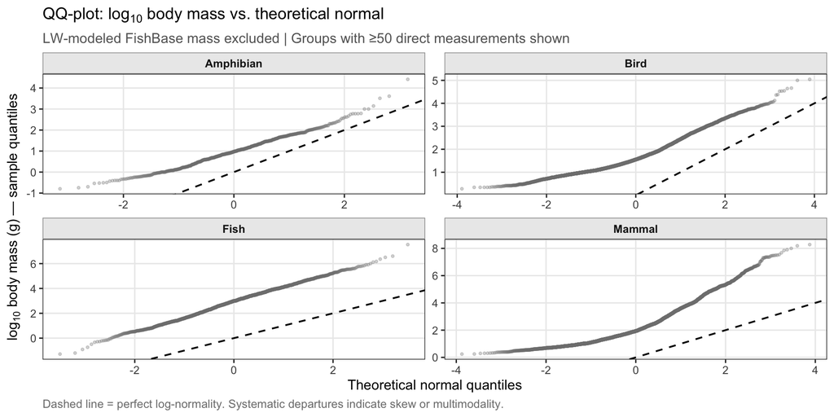

```r
## QQ plot by group — Telford: diagnostics before interpretation
qq_dat <- dat |>
  dplyr::filter(!is.na(log10_mass), is.finite(log10_mass),
                !grepl("LW_model", mass_type, ignore.case = TRUE)) |>
  dplyr::group_by(group_display) |>
  dplyr::filter(dplyr::n() >= 50) |>  # only groups with ≥50 wet/direct rows
  dplyr::mutate(
    theoretical = {
      n <- dplyr::n()
      stats::qnorm(seq(0.5/n, 1 - 0.5/n, length.out = n))
    },
    sample_quantile = sort(log10_mass)
  ) |>
  dplyr::ungroup()

ggplot(qq_dat, aes(x = theoretical, y = sample_quantile, colour = group_display)) +
  geom_point(alpha = 0.3, size = 0.8) +
  geom_abline(slope = 1, intercept = 0, colour = "black", linewidth = 0.7,
              linetype = "dashed") +
  scale_colour_manual(values = GROUP_COLOURS, guide = "none") +
  facet_wrap(~ group_display, scales = "free") +
  labs(
    title    = expression("QQ-plot: log"[10]*" body mass vs. theoretical normal"),
    subtitle = "LW-modeled FishBase mass excluded | Groups with ≥50 direct measurements shown",
    caption  = "Dashed line = perfect log-normality. Systematic departures indicate skew or multimodality.",
    x        = "Theoretical normal quantiles",
    y        = expression("log"[10]*" body mass (g) — sample quantiles")
  )
```

```r
## Summary statistics — what enhanced-theory would want to see
scale_stats <- dat |>
  dplyr::filter(!is.na(log10_mass), is.finite(log10_mass)) |>
  dplyr::group_by(group_display) |>
  dplyr::summarise(
    n              = dplyr::n(),
    min_g          = min(mass_g, na.rm = TRUE),
    max_g          = max(mass_g, na.rm = TRUE),
    median_g       = median(mass_g, na.rm = TRUE),
    mean_log10     = mean(log10_mass, na.rm = TRUE),
    sd_log10       = sd(log10_mass, na.rm = TRUE),
    range_decades  = diff(range(log10_mass, na.rm = TRUE)),
    .groups        = "drop"
  )

scale_stats |>
  dplyr::mutate(
    min_g      = round(min_g, 2),
    max_g      = scales::comma(round(max_g, 0)),
    median_g   = scales::comma(round(median_g, 1)),
    mean_log10 = round(mean_log10, 2),
    sd_log10   = round(sd_log10, 2),
    range_decades = round(range_decades, 1)
  ) |>
  knitr::kable(
    col.names = c("Group", "n", "Min (g)", "Max (g)", "Median (g)",
                  "Mean log₁₀", "SD log₁₀", "Range (decades)"),
    caption   = "Table 5. Body mass summary statistics by taxonomic group. 'Range (decades)' = orders of magnitude spanned by group."
  )
```

Table 5. Body mass summary statistics by taxonomic group. ‘Range (decades)’ = orders of magnitude spanned by group.

| Group | n | Min (g) | Max (g) | Median (g) | Mean log₁₀ | SD log₁₀ | Range (decades) |
| --- | --- | --- | --- | --- | --- | --- | --- |
| Amphibian | 609 | 0.16 | 26,000 | 9 | 0.99 | 0.76 | 5.2 |
| Bird | 10164 | 1.90 | 111,000 | 36 | 1.70 | 0.69 | 4.8 |
| Fish | 5657 | 0.01 | 34,000,000 | 264 | 2.41 | 1.23 | 9.7 |
| Mammal | 9364 | 1.75 | 190,000,000 | 86 | 2.27 | 1.25 | 8.0 |
| Reptile | 16 | 15.70 | 32,000 | 415 | 2.58 | 1.02 | 3.3 |

## 7.3 Cross-group mass scaling context

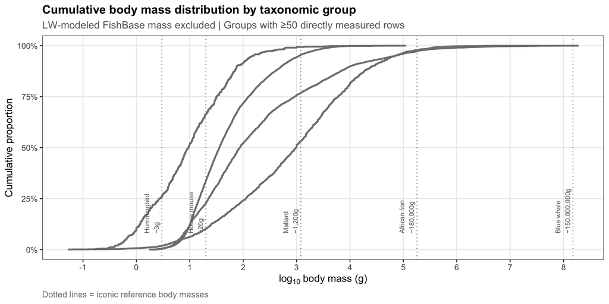

```r
ecdf_dat <- dat |>
  dplyr::filter(!is.na(log10_mass), is.finite(log10_mass),
                !grepl("LW_model", mass_type, ignore.case = TRUE)) |>
  dplyr::group_by(group_display) |>
  dplyr::filter(dplyr::n() >= 50) |>
  dplyr::ungroup()

## Reference masses (log10 g)
reference_masses <- data.frame(
  label = c("Hummingbird\n~3g", "House mouse\n~20g",
            "Mallard\n~1,200g", "African lion\n~180,000g",
            "Blue whale\n~150,000,000g"),
  log10_g = c(log10(3), log10(20), log10(1200),
               log10(180000), log10(1.5e8))
)

ggplot(ecdf_dat, aes(x = log10_mass, colour = group_display)) +
  stat_ecdf(linewidth = 1, pad = FALSE) +
  geom_vline(data = reference_masses, aes(xintercept = log10_g),
             linetype = "dotted", colour = "grey50", linewidth = 0.5) +
  geom_text(data = reference_masses, aes(x = log10_g, y = 0.08, label = label),
            inherit.aes = FALSE, size = 2.8, angle = 90, hjust = 0,
            vjust = -0.2, colour = "grey40") +
  scale_colour_manual(values = GROUP_COLOURS, name = "Taxonomic group") +
  scale_x_continuous(
    name   = expression(log[10]~"body mass (g)"),
    breaks = -2:9
  ) +
  scale_y_continuous(name = "Cumulative proportion", labels = scales::percent) +
  labs(
    title    = "Cumulative body mass distribution by taxonomic group",
    subtitle = "LW-modeled FishBase mass excluded | Groups with ≥50 directly measured rows",
    caption  = "Dotted lines = iconic reference body masses"
  )
```